# Project 3

### Created by Asif Chowdhury, Justin Owens, Jash Choraria

This is the third project for CS 329E Data Visualization. The data we will analyze comes from the Enigma.io website. The topic is a relationship between federal election campaign contributors and their income in Texas in 2008. In order to reproduce this project, please follow the following instructions.

## Step 1

#### Load the correct packages

Use the following code to load the correct packages into RStudio.

```r
source("../01 Data/Packages.R", echo = FALSE)
```

## Step 2

#### Import the data from the Oracle cloud server.

The TX_CONT data table has the following 5 columns: ID, Amount, Gender, Zipcode, Party

```r
source("../01 Data/TX_INCOME.R", echo = FALSE)
head(TX_INCOME)
```

```
##   ZIPCODE GROSS_INCOME    WAGES   TAXES INCOME_TAX
## 1   75158     10762587  6424915  158285    2358392
## 2   75159      4601329  4479755   74952      17067
## 3   75159     30214339 24568282  358500     602855
## 4   75159     73201469 64820989 1488987    3234435
## 5   75159     54570767 48288820 1343241    4199955
## 6   75159     39399490 34767130 1032237    3631906
```

```r
source("../01 Data/TX_CONT.R", echo = FALSE)
head(TX_CONT)
```

```
##          ID AMOUNT GENDER ZIPCODE PARTY
## 1 218639142    250      M   78250     R
## 2 218639143   1000      M   79604     R
## 3 218639145    618      F   77057     R
## 4 218639146    500      M   79416     R
## 5 218639150   1000      F   78247     R
## 6 218639151   2100      M   76102     R
```

## Step 3

#### Use data wrangling to create smaller dataframes for visualizations.

With the two data tables, we successfully performed a series of data wrangling join operations to create a coherent and correlated data set. In order to create interesting visualizations, we first had to modify the TX_INCOME data table to provide us with the average income of people in Texas based on their zipcodes.

```r
source("../02 Data Wrangling/AVE_INC_ZIP.R", echo = FALSE)
head(AVE_INC_ZIP)
```

```
## Source: local data frame [6 x 5]
##
##   ZIPCODE AverageIncome AverageWages AverageTax AverageIncomeTax
## 1   73301       1161116      1132386      74400         101098.2
## 2   75001      85324288     56311920    2104098       14258311.7
## 3   75002     284114388    243690862   12345289       36031657.3
## 4   75006     148741551    119040883    4092328       16603387.6
## 5   75007     220268495    183240881    7735568       26677691.4
## 6   75009      34819131     26600475    1454860        4337333.7
```

It would be interesting to compare how gender influences political contributions and its realtionship with income. We manipulated the TX_CONT data table to give us the average amount contributed by the number of people of different gender to different parties for each zipcode.

```r
source("../02 Data Wrangling/GENDER_COUNT.R", echo = FALSE)
head(GENDER_COUNT)
```

```
## Source: local data frame [6 x 5]
## Groups: ZIPCODE, GENDER
##
##   ZIPCODE GENDER PARTY Count AverageContribution
## 1   73479      M  null     1                 250
## 2   73604      M     D     1                1000
## 3   73701      M  null     1                 500
## 4   74003      M     R     1                1000
## 5   74055      M     D     1                 250
## 6   74057      F     R     2                   0
```

The following data frame is the result of an inner join, joining the data frame only from the rows that actually match based on zipcode. The table is joined data set of contribution data set and income data set. The results have been grouped by zipcode and ID. It shows each ID’s contributed amount and average income, wages and taxes.

```r
source("../02 Data Wrangling/innerjoin.R", echo = FALSE)
head(INNERJOIN)
```

```
## Source: local data frame [6 x 7]
## Groups: ID
##
##          ID ZIPCODE Amount AverageIncome AverageWages AverageTaxes
## 1 218639142   78250    250     157674254    134696480    4632007.1
## 2 218639143   79604   1000      14563980      3240227     250418.3
## 3 218639145   77057    618     297291406    169683613    8228825.6
## 4 218639146   79416    500      93652161     68260295    1942779.1
## 5 218639150   78247   1000     164670191    138909601    6154173.7
## 6 218639151   76102   2100     198008811     45205215    5923585.6
## Variables not shown: AverageIncomeTax (dbl)
```

We also performed an outer join on the gender-based political contribution and average income by zipcode data sets. This common predicate was the zipcode, allowing us to compare gender contributions based on income to federal campaign elections. The data is then grouped by gender and party and the average of the two columns is taken.

```r
source("../02 Data Wrangling/outerjoin.R", echo = FALSE)
head(OUTERJOIN)
```

```
## Source: local data frame [6 x 7]
## Groups: GENDER
##
##   PARTY GENDER AverageContribution AverageWages AverageIncome AverageTax
## 1     3      F           1030.6667    135700572     233644783    7022958
## 2     D      F            654.6173     56356094      77769262    2276878
## 3     I      F            691.6364    118540453     188229566    6241674
## 4     L      F            394.4444    121542649     187714463    6196750
## 5  null      F            647.4384     66871363      93703442    2837979
## 6     R      F            814.0637     46054193      63983071    1844972
## Variables not shown: AverageIncomeTax (dbl)
```

A semi join data wrangling operation was perfromed on the Gender-based political contribution table and the average income by zipcode data set, both which were manipulated above. this data set has all the rows of gender-based political contribution data set that has a match in averaege income by zipcode data frame.

```r
source("../02 Data Wrangling/SEMI_JOIN.R", echo = FALSE)
head(SEMI_JOIN)
```

```
## Source: local data frame [6 x 5]
## Groups: ZIPCODE, GENDER
##
##   ZIPCODE GENDER PARTY Count AverageContribution
## 1   75001      F     D    15            409.6000
## 2   75001      F  null     5            600.0000
## 3   75001      F     R    59           3377.3390
## 4   75001      M     D    52            805.2115
## 5   75001      M     I     1           2300.0000
## 6   75001      M  null    31           2476.1290
```

## Step 4

#### Use ggplot and the newly “wrangled” data frames to create interesting visuals.

We will now create the interesting visuals for all of the dataframes we have “wrangled” in step 3.

Visualization 1 - This visualization shows us the relationship between income and taxes. The United States of America follows a progressive tax system; greater your income, higher your tax bracket.The scatter plot with the line of best fit, created using the average income by zipcode data set, follows the same trend. As income increases, so does taxes paid. The scatter points, with respect to the line of the best fit, is interesting in this visualization. For smaller incomes, majority of the points lie below the line of best fit, while for those with larger incomes pay higher taxes compared to the average. One could potentially attribute this finding to the relative value of money. For people with smaller incomes, every penny saved in taxes significantly influences your real income as compared to those who make a lot more money and can afford to pay taxes in full.

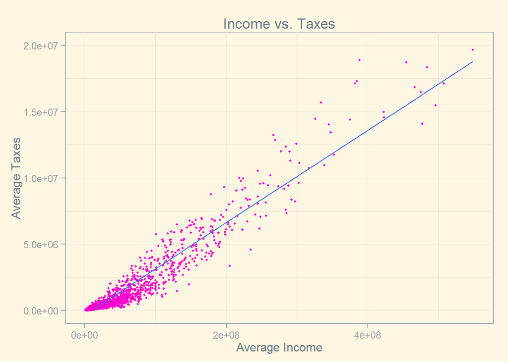

```r
source("../03 Visualizations/AverageIncomePlot.R", echo = FALSE)
g
```

Visualization 2 - After wrangling the two respective data sets, the following visualization shows the relationship between federal campaign contributions and averages taxes. Taxes paid are a good representation of the wealth bracket one falls under. By comparing this to contributions, we can look to find a relationship, if it exists, between taxes and federal campaign contributions. The results are of particular interest as there seems to be no correlation between the two. Infact, people with low incomes and average taxes make more personal contributions to federal elections. Most people in Texas contribute close to the same amount. Further analysis and research helps explains this trend in political contributions. More wealthy members contribute through PACs, special interest groups and business organizations in much larger denominations, consequently do not make large personal federal campaign contributions.

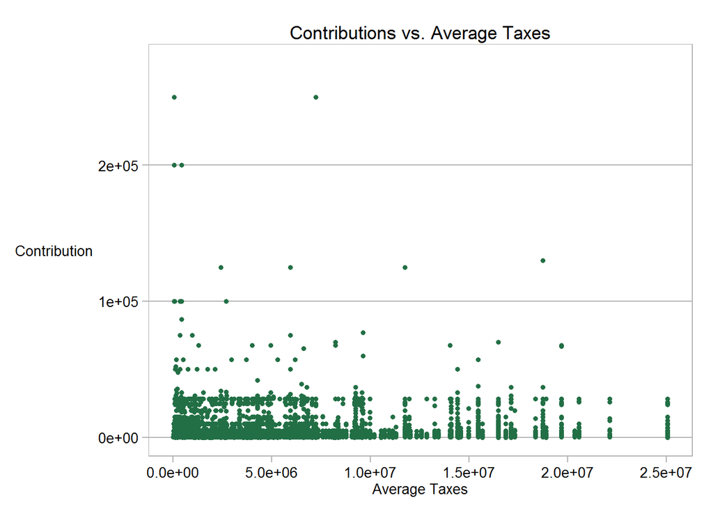

```r
source("../03 Visualizations/InnerJoinPlot.R", echo = FALSE)
g
```

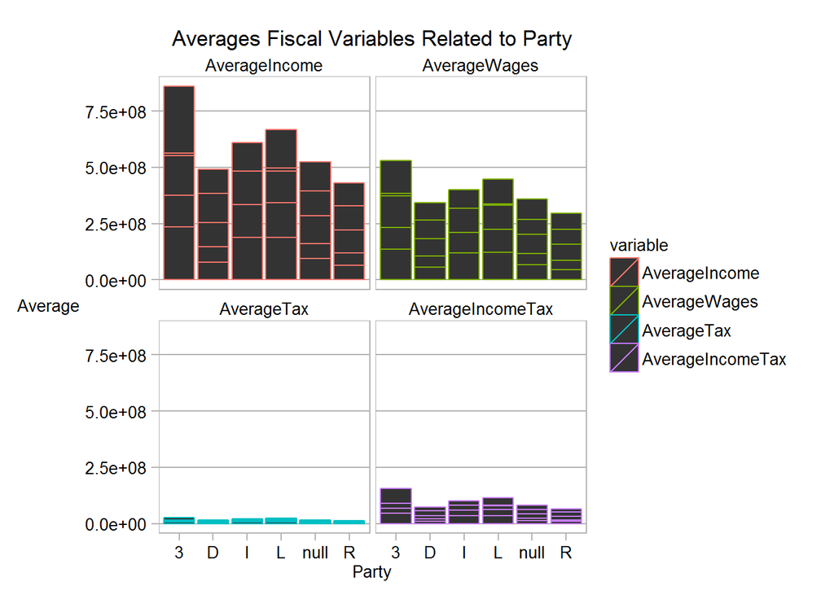

```r
source("../03 Visualizations/OuterJoinPlot.R", echo = FALSE)
g
```

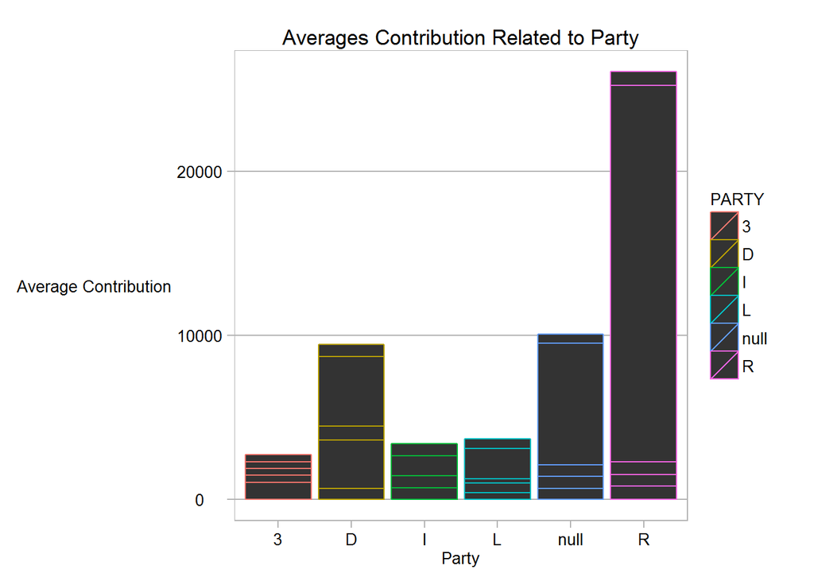

```r
j
```

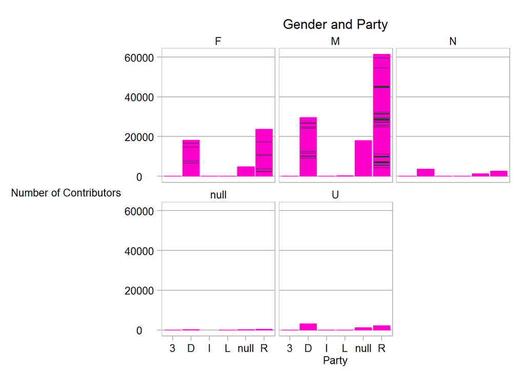

```r
source("../03 Visualizations/SemiJoinPlot.R", echo = FALSE)
g
```

## Step 5

#### Use ggplot and categories of the Texas Contribution dataset to create two png file.

FIRST PNG: The first png file contains two graphs of the following categorical variables: Gender and Party. The first graph shows the number of contributers by each gender. Gender has the categories of five different groups known as Male (M), Female (F), Not Specified (N), No Data (Null) and Unisex (U). The second graph shows the number of contributors for each party. The graph contains six different political parties known as 3 (3), Democratic (D), Independent (I), Liberal (L), No Data (NULL) and Republican (R)

SECOND PNG: The second png file contains three histogram graphs for the following three quantitative variables: ID, Amount and Zipcode.

```r
source("../03 visualizations/PngCategoricals.R", echo = FALSE)
```

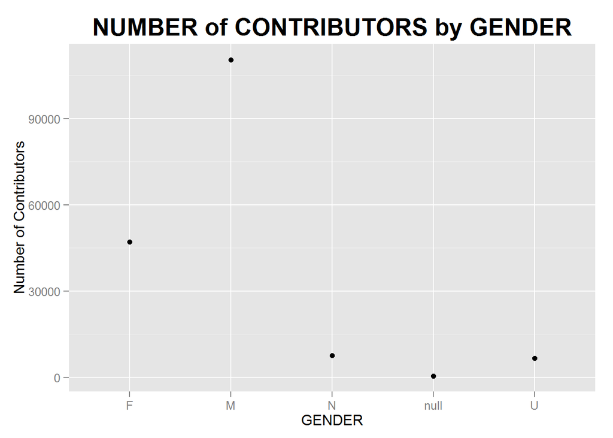

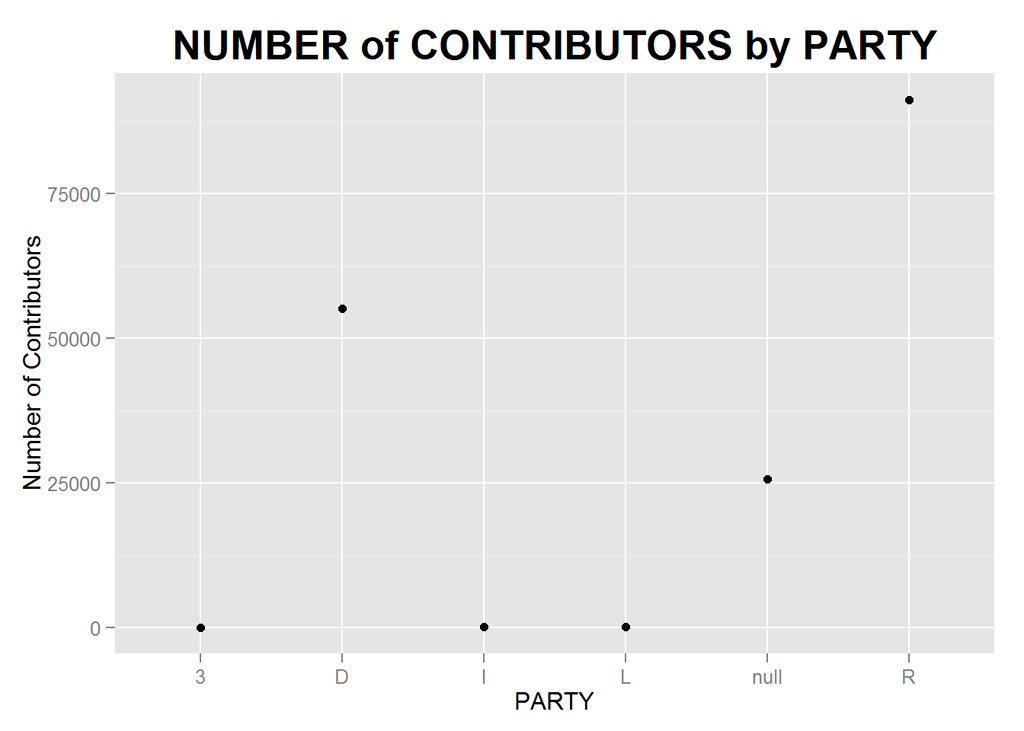

```
## stat_bin: binwidth defaulted to range/30. Use 'binwidth = x' to adjust this.
```

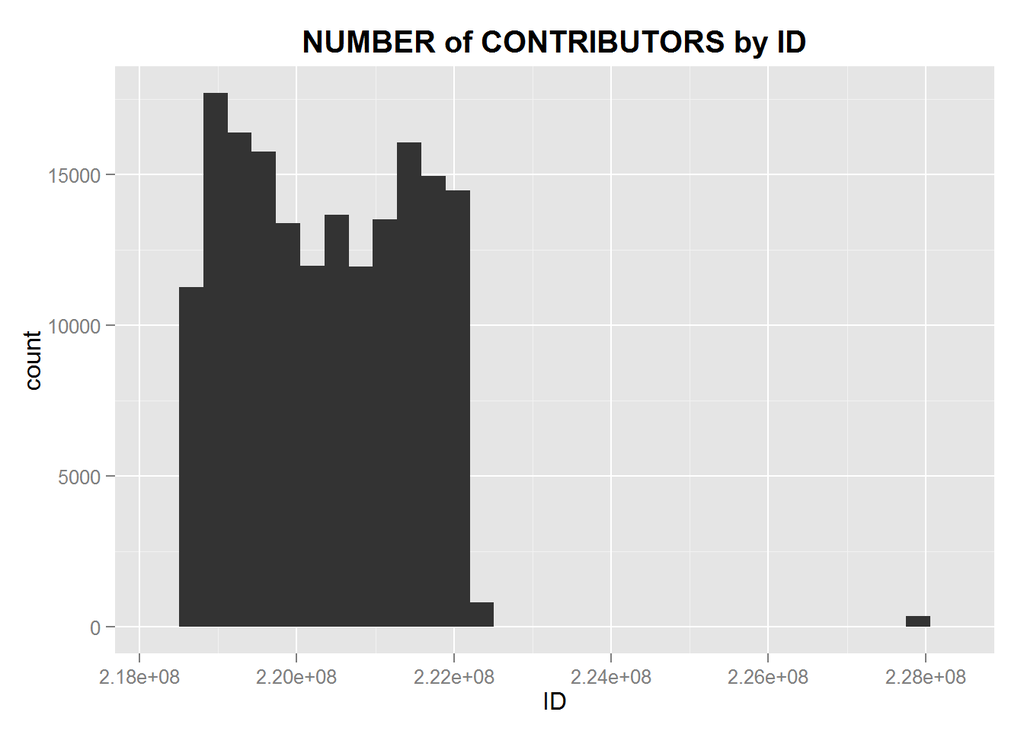

```
## stat_bin: binwidth defaulted to range/30. Use 'binwidth = x' to adjust this.
```

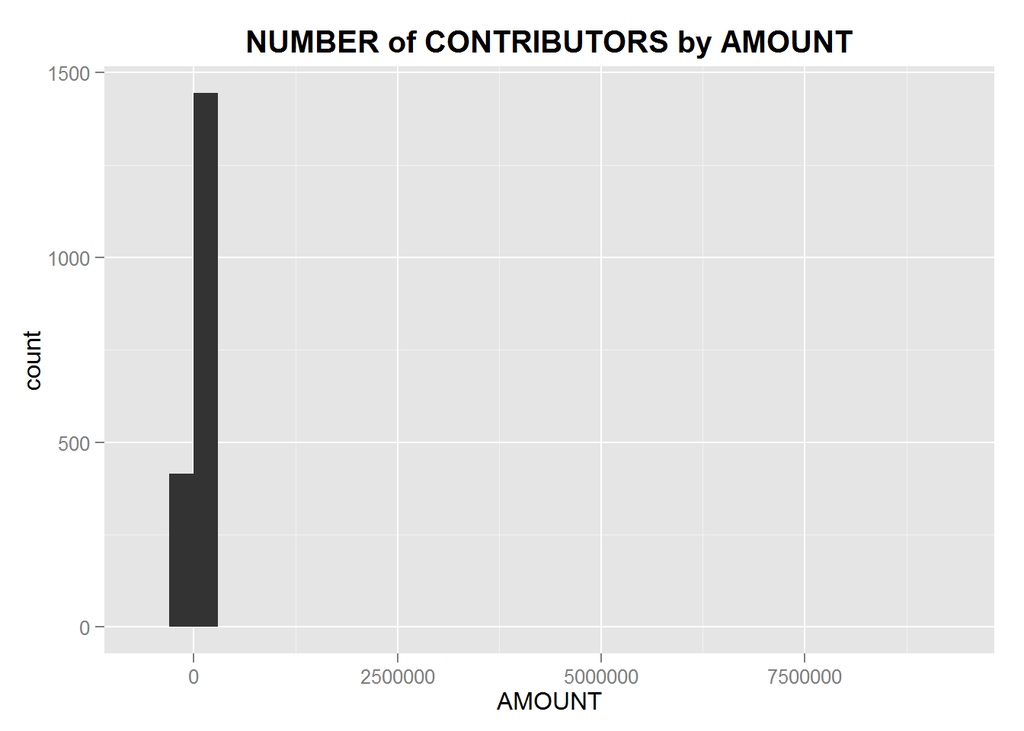

```
## stat_bin: binwidth defaulted to range/30. Use 'binwidth = x' to adjust this.
```

```
## stat_bin: binwidth defaulted to range/30. Use 'binwidth = x' to adjust this.
```

[figure not shown]